# Setup Env(MASK R-CNN)

## Step 1: Activate WSL and Install Ubuntu

- There are two ways to activate WSL and install Ubuntu:

### Option 1: Enable WSL via PowerShell

1. Open PowerShell as Administrator.
2. Run the following command:

   ```
   wsl --install
   ```

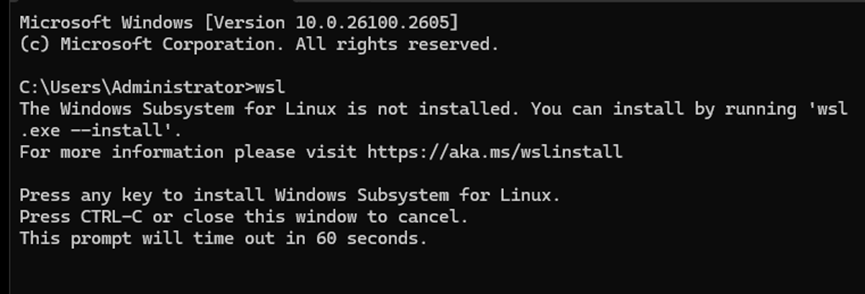

3. When prompted, choose `Ubuntu` as your Linux distribution.

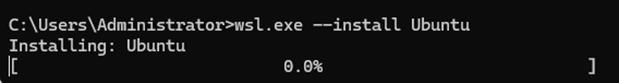

### Option 2: Install `Ubuntu` from `Microsoft Store`

1. Open Microsoft Store on Windows.
2. Search for `Ubuntu` and install the latest version.

[figure not shown]

3. Launch `Ubuntu` and complete the initial setup.

## Step 2: Install Docker and Set Up TensorFlow Container

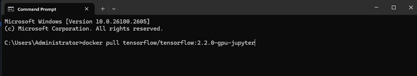

[figure not shown]

## Step 3: Set Up VS Code with Docker & Dev Containers

1. Open `Visual Studio Code`.
2. Install the following extensions (`Ctrl+Shift+X` → Search → Install):
   - Dev Containers
   - Docker

[figure not shown]

3. Attach VS Code to the TensorFlow container:
   - Press `F1`, type `Remote-Containers: Attach to Running Container`, and select the `TensorFlow container`.

[figure not shown]

## Step 4: Load the Kangaroo Transfer Learning Project

- In `VS Code`’s terminal, add the Kangaroo Transfer Learning folder to your workspace:

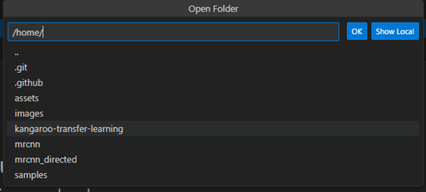

## Step 5: Update & Install Dependencies

1. Open the `requirements.txt` file in the project directory.
2. Modify package versions if needed.

[figure not shown]

3. Install dependencies inside the `Docker container`:

   ```
   pip install -r requirements.txt
   ```

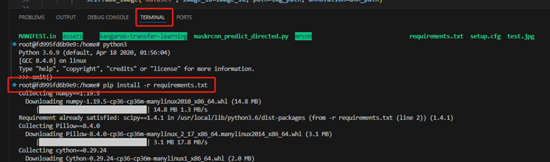

## Step 6: Download Pre-Trained Weights

1. Download the `mask_rcnn_coco.h5` file from `Mask R-CNN 2.0`.
   - [Download Link](https://github.com/matterport/Mask_RCNN/releases)
2. Place the file in the appropriate project folder.

## Step 7: Run the Kangaroo Training Script

2. Start training:

   ```
   python3 kangaroo_training.py
   ```

## Step 8: Test Model with a Sample Image

1. Locate an image in /kangaroo/images.
2. Rename the selected image to sample2.jpg.
3. Run the prediction script to evaluate the model:

   ```
   python3 kangaroo_prediction.py
   ```

## Troubleshooting Common Issues

- ❌ ImportError: `libGL.so.1` Not Found
- Fix by running:

  ```
  pip uninstall opencv-python
  pip install opencv-python-headless
  ```

## Conclusion

By using Docker for machine learning, you achieve a reproducible, scalable, and efficient workflow for deep learning applications. With WSL and VS Code integration, developers can seamlessly train models while maintaining the flexibility of Linux and Windows environments.

🚀 Happy coding! 🖥️🐍📦

2025-09-18 2025-09-18